# Pre Lab 08

Sonja

27/10/2021

## Lab 08: Modeling 1

In this lab, we’ll be using bootstrap resampling to explore sampling distributions of model parameters in the context of one and two sample difference of means tests.

#### Worked with:

Justin Roch and Aliza Fassler

```
##
##  Welch Two Sample t-test
##
## data:  flipper_length_mm by species
## t = -5.7804, df = 119.68, p-value = 3.025e-08
## alternative hypothesis: true difference in means is less than 0
## 95 percent confidence interval:
##       -Inf -4.186534
## sample estimates:
##    mean in group Adelie mean in group Chinstrap
##                189.9536                195.8235
```

#### Q1

Calculate the standard deviation of the differences in mean flipper length from your bootstrap simulation. Show the R-code you used to find do the calculation.

```r
mean(pen_boot$t)
```

```
## [1] -5.888359
```

```r
sd(pen_boot$t)
```

```
## [1] 1.009889
```

#### Q2

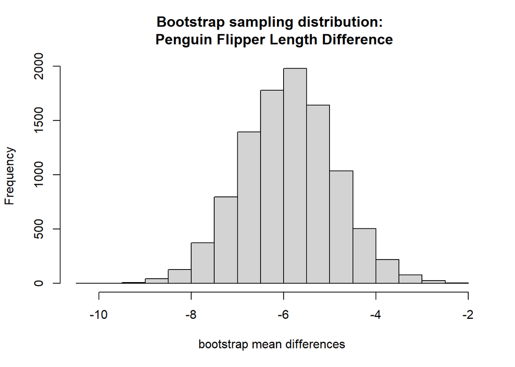

#### Q3

What was the 95% bootstrap CI you calculated using quantile()? Show the R-code you used to answer the question.

```r
quantile(
  pen_boot$t,
  c(0.025, 0.975))
```

```
##      2.5%     97.5%
## -7.872616 -3.895852
```

#### Q4

Do you think the resampled differences in means follow a skewed distribution?

The resampled differences in means looks relatively normally distributed. The histogram shows the mean and the median visually appear to be the same, around -5.87.

### Penguin ECDF

#### Q5

Show the R-code you used to create pen_ecdf()

```r
pen_ecdf=ecdf(pen_boot$t)
```

#### Q6

What is the probability, according to the empirical distribution function, of observing a mean difference of -4.5 or greater?

```r
1-pen_ecdf(-4.5)
```

```
## [1] 0.0828
```

#### Q7

What is the probability, according to the empirical distribution function, of observing a mean difference of -8 or smaller?

```r
pen_ecdf(-8)
```

```
## [1] 0.0179
```

### Hypothesis

#### Q8

The null hypothesis is that there is no difference between mean flipper length between the Adelie and Chinstrap penguins.

The alternative hypothesis is that there is a difference between mean flipper length between the Adelie and Chinstrap penguins.

### Pines, Non-Parametric Test

#### Q9

What was the p-value? Show the R-code you used to find out.

```r
wilcox.test(pine~treatment,
            data=dat_tree,
            alternative = "two.sided")
```

```
##
##  Wilcoxon rank sum test with continuity correction
##
## data:  pine by treatment
## W = 48, p-value = 0.1005
## alternative hypothesis: true location shift is not equal to 0
```

The p-value is = 0.1005

### Pines, Boostrap

#### Q10

What were the endpoints of your bootstrap CI? Show the R-code you used to find out.

```r
quantile(tree_boot$t, 0.975)
```

```
## 97.5%
## 29.75
```

```r
quantile(tree_boot$t, 0.025)
```

```
## 2.5%
## 4.25
```

#### Q11

What is the observed difference in mean tree counts and does it fall within the 95% bootstrap CI?

```
##   treatment   pine
## 1   clipped 17.875
## 2   control  1.875
```

The observed difference is 16 and it falls within the 95% bootstrap CI.

### Resampling Model Coefficients

#### Q12

The Simpson diversity index measures the diversity of the system of interest. It does this by using both the species richness and species abundance.

#### Q13

Show the code you used to z-standardize the s.sidi column

```r
dat_1 =
  subset(
    dat_all,
    select = c(b.sidi, s.sidi))

# Calculate the sample mean and sd:
s_sidi_mean = mean(dat_all$s.sidi, na.rm = TRUE)
s_sidi_sd   = sd(dat_all$s.sidi, na.rm = TRUE)

# Use the subset-by-name symbol ($) to create a
# new column of z-standardized values.

dat_all$s.sidi.standardized = (dat_all$s.sidi - s_sidi_mean)/s_sidi_sd
```

#### Q14

Complete the code for a loop to resample the slope parameter of a simple linear regression of the Simpson’s diversity indices for vegetation and birds

```r
m = 10000
result = numeric(m)

for(i in 1:m)
{
  index_1 = sample(nrow(dat_1), replace = TRUE)
  index_2 = sample(nrow(dat_1), replace = TRUE)

 dat_resampled_i =
  data.frame(
    b.sidi = dat_1$b.sidi[index_1],
    s.sidi = dat_1$s.sidi[index_2]
  )

fit_resampled_i = lm(b.sidi ~ s.sidi, data = dat_resampled_i)

  result[i] = coef(fit_resampled_i)[2]
}
```

#### Q15

In your report, include a plot of your histogram with vertical lines showing the observed slope and the critical value from the resampled MC slopes.

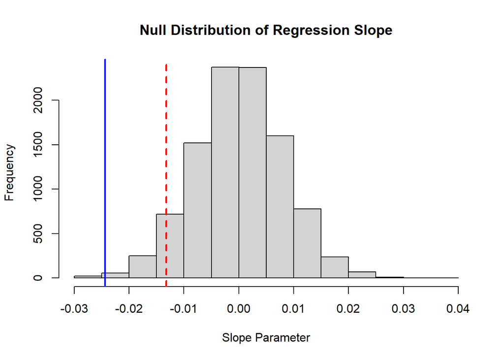

#### Q16

What was your critical value? Was the observed slope less than the critical value?

```
##          5%
## -0.01325218
```

```
##      s.sidi
## -0.02437131
```

#### Q17

What is your conclusion regarding the evidence of a negative relationship between vegetation cover diversity and bird diversity? Make sure to justify your conclusions using the results of your analysis.

It appears that there could be a negative relationship between the Simpson’s diversity index of vegetation and birds. The model of the observed data illustrate that as the Simpson’s diversity index of vegetation cover in the bird’s habitat increases the Simpson’s diversity index for the birds decreases. From the results of the analysis I see that the slope calculated from the fitted model from the observed data is sufficiently unlikely to have occurred given the distribution of all the possible slope values in the Null model as calculated from the MC loop.The Null model assumed that there is no relationship between the Simpson’s diversity index of birds and vegetation. The critical value at 0.05 % of the Null model distribution of the possible slopes is -0.013 while the value of the observed slope was even smaller, -0.024 and more extreme than values within a confidence interval of 95% for the critical values.